# Comandes générales et visualisation bivariée

Python works with packages. A large number of packages can be dowloaded all together in the Anaconda environment. Start downloading here (version >3) https://www.anaconda.com/download/ Anaconda comes with

- Spyder, a GUI for python
- Jupyter Notebook, how to create great documents

Enjoy!

Bee careful :

- Python is sensible to spaces in the beginning of lines,
- Python is sensible to number type : $3$ and $3.$ are totally different: *integer* and *float* types.

```python
import warnings
warnings.filterwarnings('ignore')
```

## 1 Handle basic instructions

```python
print(1+2) # SUM #First operation and first comment
print(2*3) # MULTIPLICATION #Second operation and second comment
#Third comment
print(4/5) # DIVISION
print(3**4)# RAISE POWER
print((25/6-2*3)**2) # COMPLEXE OPERATION
print("Hello World")
```

```
3
6
0.8
81
3.36111111111111
Hello World
```

## 2 The Variables

### 2.1 Create the variables

```python
my_integer = 54213
my_float = 21.514302
my_string = "Hello World"
```

### 2.2 Check the variables

```python
print(my_integer)
print(my_float)
print(my_string)
```

```
54213
21.514302
Hello World
```

### 2.3 Test the variables

#### *integer* against *float*

```python
print(my_integer > my_float)
print(my_integer != my_float)
print(my_integer == my_float)
print(my_integer < my_float)
```

```
True
True
False
False
```

#### *integer* against *string*

##### Those which work...

```python
print(my_integer != my_string)
print(my_integer == my_string)
```

```
True
False
```

##### ... and those which don't

```python
# print(my_integer > my_string)
# print(my_integer < my_string)
```

## 3 The Python one-dimensional structures

### 3.1 Lists

Contain items separated by commas and enclosed within square brackets $[]$.  
Each element can be modified.

```python
my_list = [54213,21.514302,"Hello World","EDO"]
my_second_list = ["Ecole","Sante",2018,"EDO"]

print(my_list)
print(my_list[0])
print(my_list[1:3])
print(my_list[2:])
print(my_second_list*2)
print(my_list + my_second_list)

my_third_list = my_list[2:]
my_third_list[1] = "On change le deuxième élément"
print(my_third_list)
```

```
[54213, 21.514302, 'Hello World', 'EDO']
54213
[21.514302, 'Hello World']
['Hello World', 'EDO']
['Ecole', 'Sante', 2018, 'EDO', 'Ecole', 'Sante', 2018, 'EDO']
[54213, 21.514302, 'Hello World', 'EDO', 'Ecole', 'Sante', 2018, 'EDO']
['Hello World', 'On change le deuxième élément']
```

### 3.2 Tuples

Contain items separated by commas and enclosed within square brackets $()$.  
NO element can be modified.

```python
my_tuple = (54213,21.514302,"Hello World","EDO")
my_second_tuple = ("Ecole","Sante",2018,"EDO")

print(my_tuple)
print(my_tuple[0])
print(my_tuple[1:3])
print(my_tuple[2:])
print(my_second_tuple*2)
print(my_tuple + my_second_tuple)

my_third_tuple = my_tuple[2:]
# my_third_tuple[1] = "On change le deuxième élément"    # --> A tester... erreur!
print(my_third_tuple)
```

```
(54213, 21.514302, 'Hello World', 'EDO')
54213
(21.514302, 'Hello World')
('Hello World', 'EDO')
('Ecole', 'Sante', 2018, 'EDO', 'Ecole', 'Sante', 2018, 'EDO')
(54213, 21.514302, 'Hello World', 'EDO', 'Ecole', 'Sante', 2018, 'EDO')
('Hello World', 'EDO')
```

### 3.3 Dictionnaries

Works on the principle of key-value.  
Dictionaries are enclosed by curly braces ${ }$ and values can be assigned and accessed using square braces $[]$.

```python
my_dict = {}
my_dict['one'] = "un en inglish"
my_dict[2]     = "deux"

my_second_dict = {'nom': 'hadrien','age':28, 'taille':1.94}


print(my_dict['one'])
print(my_dict[2])
print(my_second_dict)
print(my_second_dict.keys())
print(my_second_dict.values())
```

```
un en inglish
deux
{'nom': 'hadrien', 'age': 28, 'taille': 1.94}
dict_keys(['nom', 'age', 'taille'])
dict_values(['hadrien', 28, 1.94])
```

### 3.4 Strings

One acceses to strings values directly using using square braces $[]$.

```python
my_string = "Hello Le Monde"
my_second_string = "Comment ca va ?"

print(my_second_string[0:7] + " donc" + my_second_string[10:14] + my_string[6:14] + my_second_string[-1])
```

```
Comment donc va Le Monde?
```

### 3.5 String operations

Very practical to generate automatic personnalized titles in figures.

```python
print("My name is %s and my weight is %d kg! My father's weight is %d kg but he is older than me!" % ('Zara', 21,95))
```

```
My name is Zara and my weight is 21 kg! My father's weight is 95 kg but he is older than me!
```

# 4 The mathematics and Python

## 4.1 Generate a list of integer or float values

The notation is *range(starting value, end value+1, step)*. The step parameter is optionnal.

```python
my_list = list(range(1,10,1))
print(my_list)
# print(math.exp(my_list))  # --> Mais on ne peut pas faire grand chose dessus...

my_list_2 = [x * 0.1 for x in range(0, 10)]
print(my_list_2) # Super on a des floats
# print(math.exp(my_list_2))   # --> Mais ca n'est pas beaucoup mieux
```

```
[1, 2, 3, 4, 5, 6, 7, 8, 9]
[0.0, 0.1, 0.2, 0.30000000000000004, 0.4, 0.5, 0.6000000000000001, 0.7000000000000001, 0.8, 0.9]
```

## 4.2 Import *numpy* and play with it

*numpy* has been thought to deal with data generic operations.

```python
import numpy as np
```

*linspace* uses the third argument to specify the number of points. The fourth argument "endpoint=True/False" permits to activate, or not, the right endpoint.

```python
my_np_linspace = np.linspace(0.,1.,11)
print(my_np_linspace)
print(np.exp(my_np_linspace))
```

```
[0.  0.1 0.2 0.3 0.4 0.5 0.6 0.7 0.8 0.9 1. ]
[1.         1.10517092 1.22140276 1.34985881 1.4918247  1.64872127
 1.8221188  2.01375271 2.22554093 2.45960311 2.71828183]
```

*arange* permits to specify the step

```python
my_np_arange = np.arange(0.0, 1.0, 0.1)
print(my_np_arange)
print(np.exp(my_np_arange))
```

```
[0.  0.1 0.2 0.3 0.4 0.5 0.6 0.7 0.8 0.9]
[1.         1.10517092 1.22140276 1.34985881 1.4918247  1.64872127
 1.8221188  2.01375271 2.22554093 2.45960311]
```

... Find the other over-exciting mathematical functions from *numpy*.

## 4.3 Plot figures : *matplotlib*

```python
import matplotlib.pyplot as plt
```

```
Text(0,0.5,'y ensemble d arrivee')
```

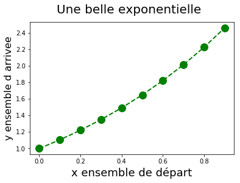

```python
fig = plt.figure()
plt.plot(my_np_arange,np.exp(my_np_arange), color='green', marker='o', linestyle='dashed',linewidth=2, markersize=12)
fig.suptitle('Une belle exponentielle', fontsize=20)
plt.xlabel('x ensemble de départ', fontsize=18)
plt.ylabel('y ensemble d arrivee', fontsize=16)
```